# 05 - Reproducible Research: Project 1

AN

27 4 2020

## Loading and preprocessing the data

```r
library(data.table)
library(dplyr)
library(lubridate)
library(lattice)
```

```r
 fileURL<-"https://d396qusza40orc.cloudfront.net/repdata%2Fdata%2Factivity.zip"
# download.file(fileURL, destfile="projectdata.zip")
# unzip("projectdata.zip", exdir=getwd())
# list.files(getwd())
data<-read.csv("activity.csv", header = TRUE, sep=",")
head(data)
```

```
##   steps       date interval
## 1    NA 2012-10-01        0
## 2    NA 2012-10-01        5
## 3    NA 2012-10-01       10
## 4    NA 2012-10-01       15
## 5    NA 2012-10-01       20
## 6    NA 2012-10-01       25
```

```r
summary(data)
```

```
##      steps                date          interval
##  Min.   :  0.00   2012-10-01:  288   Min.   :   0.0
##  1st Qu.:  0.00   2012-10-02:  288   1st Qu.: 588.8
##  Median :  0.00   2012-10-03:  288   Median :1177.5
##  Mean   : 37.38   2012-10-04:  288   Mean   :1177.5
##  3rd Qu.: 12.00   2012-10-05:  288   3rd Qu.:1766.2
##  Max.   :806.00   2012-10-06:  288   Max.   :2355.0
##  NA's   :2304     (Other)   :15840
```

```r
data$date<-ymd(data$date)
```

## What is mean total number of steps taken per day?

1. Calculate the total number of steps taken per day

```r
total.perday<-aggregate(steps~date, data, sum, na.action = NULL)
head(total.perday)
```

```
##         date steps
## 1 2012-10-01    NA
## 2 2012-10-02   126
## 3 2012-10-03 11352
## 4 2012-10-04 12116
## 5 2012-10-05 13294
## 6 2012-10-06 15420
```

2. If you do not understand the difference between a histogram and a barplot, research the difference between them. Make a histogram of the total number of steps taken each day.

```r
range(total.perday$steps)
```

```
## [1] NA NA
```

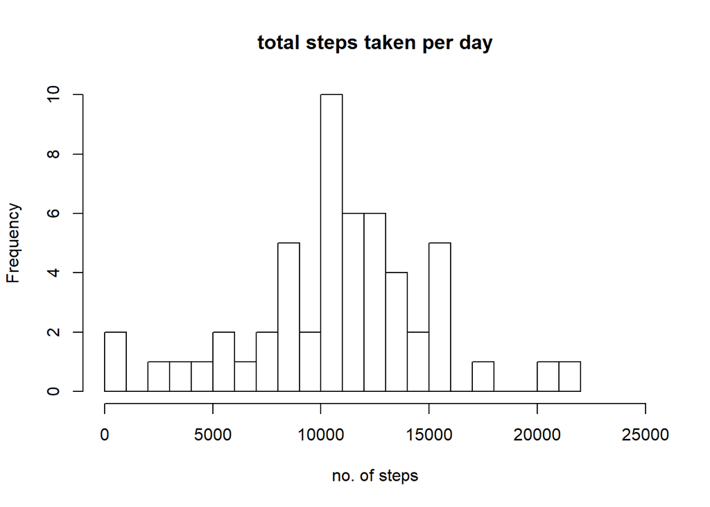

```r
# png(filename="fig1.png")
hist(total.perday$steps, main = "total steps taken per day", xlab = "no. of steps", breaks=seq(0, 22000,1000), xlim=c(0, 25000))
```

```r
# dev.off()
```

3. Calculate and report the mean and median of the total number of steps taken per day

```r
median.perday<-median(total.perday$steps, na.rm=TRUE)
mean.perday<-mean(total.perday$steps, na.rm = TRUE)
median.perday
```

```
## [1] 10765
```

```r
mean.perday
```

```
## [1] 10766.19
```

-> Median is 10765, mean is 10766.19.

## What is the average daily activity pattern?

1. Make a time series plot (i.e. 𝚝𝚢𝚙𝚎 = “𝚕”) of the 5-minute interval (x-axis) and the average number of steps taken, averaged across all days (y-axis)

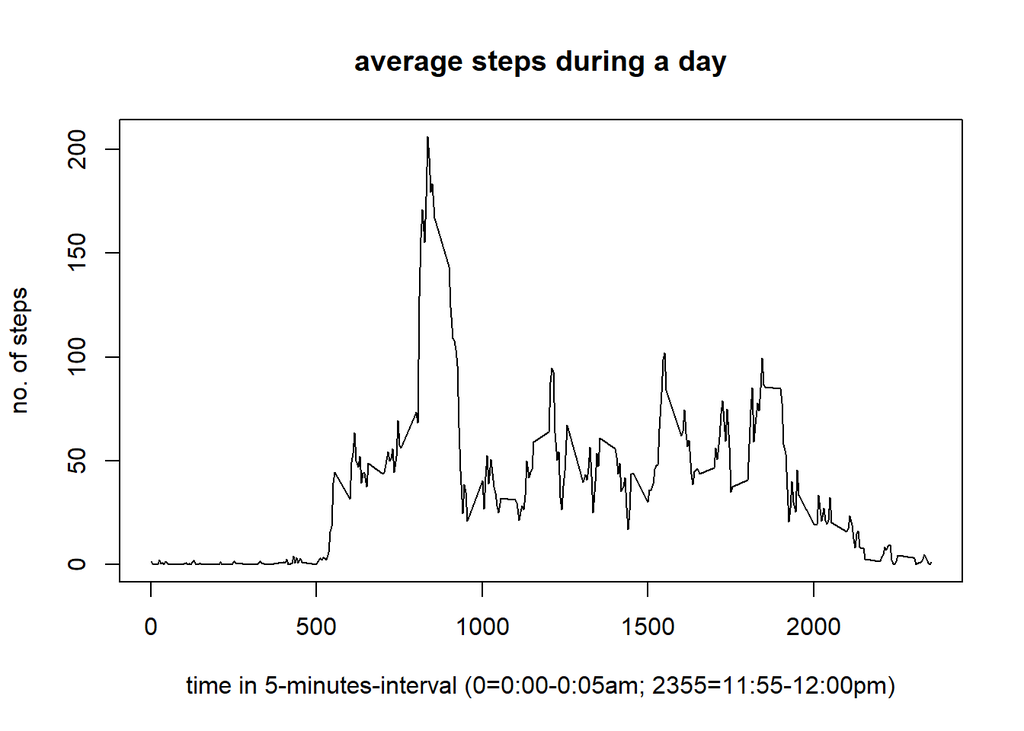

```r
mean.perint<-aggregate(steps~interval,data, mean, na.rm=TRUE)
# png(filename = "fig2.png")
plot(mean.perint$interval, mean.perint$steps, type="l", main="average steps during a day", ylab="no. of steps", xlab="time in 5-minutes-interval (0=0:00-0:05am; 2355=11:55-12:00pm)")
```

```r
# dev.off()
```

2. Which 5-minute interval, on average across all the days in the dataset, contains the maximum number of steps?

```r
max.steps<-max(mean.perint$steps)
max.int<-as.numeric(subset(mean.perint, steps==max(mean.perint$steps))[,1])
print(max.int)
```

```
## [1] 835
```

## Imputing missing values

1. Calculate and report the total number of missing values in the dataset (i.e. the total number of rows with 𝙽𝙰s

```r
# number of rows with NAs (only steps has NAs)
nrow(data[is.na(data$steps),])
```

```
## [1] 2304
```

```r
# percentage of observables with NAs
nrow(data[is.na(data$steps),])/nrow(data)*100
```

```
## [1] 13.11475
```

2. Devise a strategy for filling in all of the missing values in the dataset. The strategy does not need to be sophisticated. For example, you could use the mean/median for that day, or the mean for that 5-minute interval, etc.

```r
# impute missings using the mean of 5-minute interval

names(mean.perint)<-c("interval", "mean.steps")

data.imp<-merge(data, mean.perint, by.x="interval", by.y = "interval" , all=TRUE)

data.imp$steps<-ifelse (is.na(data.imp$steps), data.imp$mean.steps, data.imp$steps)

# for assertion:
sum(is.na(data.imp$steps))
```

```
## [1] 0
```

3. Create a new dataset that is equal to the original dataset but with the missing data filled in.

```r
data.new<-data.imp[, 1:3]
head(data.new)
```

```
##   interval    steps       date
## 1        0 1.716981 2012-10-01
## 2        0 0.000000 2012-11-23
## 3        0 0.000000 2012-10-28
## 4        0 0.000000 2012-11-06
## 5        0 0.000000 2012-11-24
## 6        0 0.000000 2012-11-15
```

4. Make a histogram of the total number of steps taken each day and calculate and report the mean and median total number of steps taken per day. Do these values differ from the estimates from the first part of the assignment? What is the impact of imputing missing data on the estimates of the total daily number of steps?

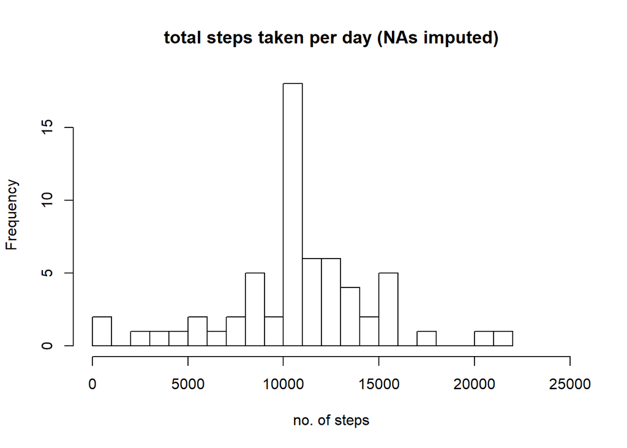

```r
total.perday.new<-aggregate(steps~date, data.new, sum)
# png(filename = "fig3.png")
hist(total.perday.new$steps, main = "total steps taken per day (NAs imputed)", xlab = "no. of steps", breaks=seq(0, 22000,1000), xlim=c(0, 25000))
```

```r
# dev.off()
median.perday.new<-median(total.perday.new$steps)
median.perday.new
```

```
## [1] 10766.19
```

```r
mean.perday.new<-mean(total.perday.new$steps)
mean.perday.new
```

```
## [1] 10766.19
```

```r
# to compare here the median and mean of steps per day calculated on the dataset with NAs:
median.perday
```

```
## [1] 10765
```

```r
mean.perday
```

```
## [1] 10766.19
```

```r
# very similar despite different number of missings:
sum(is.na(total.perday$steps))
```

```
## [1] 8
```

```r
sum(is.na(total.perday.new$steps))
```

```
## [1] 0
```

```r
# the 2000 missings occur on very few days
```

## Are there differences in activity patterns between weekdays and weekends?

1. Create a new factor variable in the dataset with two levels – “weekday” and “weekend” indicating whether a given date is a weekday or weekend day.

```r
data.new$wday<-factor(wday(data.new$date, label=TRUE))
data.new$weekend<-factor(ifelse(as.numeric(data.new$wday) %in% 2:6, 0, 1), labels = c("weekday", "weekend"))
head(data.new)
```

```
##   interval    steps       date wday weekend
## 1        0 1.716981 2012-10-01   Mo weekday
## 2        0 0.000000 2012-11-23   Fr weekday
## 3        0 0.000000 2012-10-28   So weekend
## 4        0 0.000000 2012-11-06   Di weekday
## 5        0 0.000000 2012-11-24   Sa weekend
## 6        0 0.000000 2012-11-15   Do weekday
```

2. Make a panel plot containing a time series plot (i.e. 𝚝𝚢𝚙𝚎 = “𝚕”) of the 5-minute interval (x-axis) and the average number of steps taken, averaged across all weekday days or weekend days (y-axis). See the README file in the GitHub repository to see an example of what this plot should look like using simulated data.

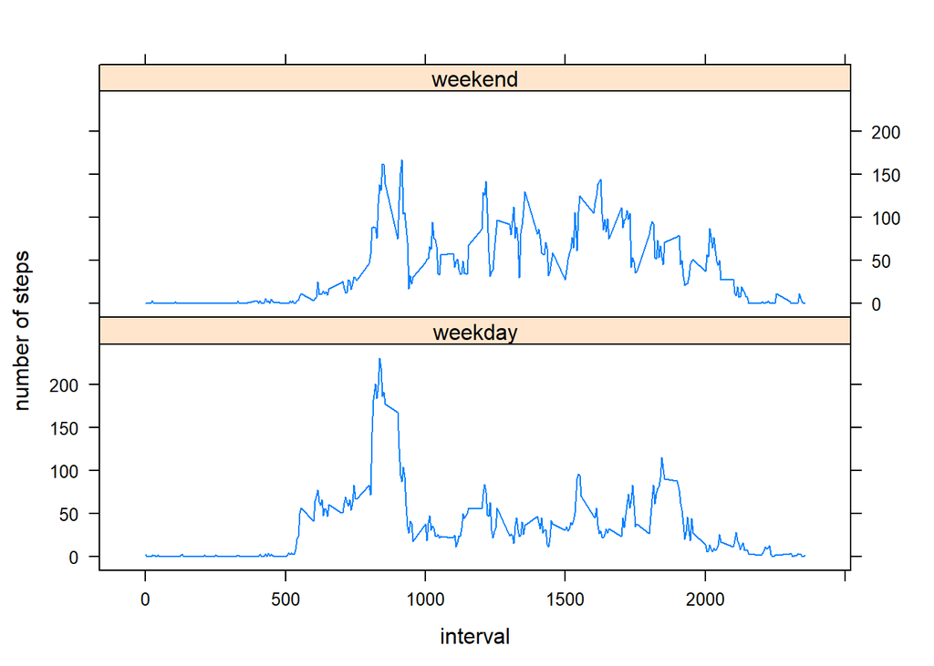

```r
mean.perint.weekend<-aggregate(steps~interval+weekend, data.new, mean)
names(mean.perint.weekend)<-c("interval", "weekend", "mean.steps")
# png(filename = "fig4.png")
xyplot(mean.perint.weekend$mean.steps ~ mean.perint.weekend$interval | mean.perint.weekend$weekend, layout = c(1, 2), type="l", ylab = "number of steps", xlab="interval")
```

```r
# dev.off()
```